# Module 1: Foundations of Value & Quality

MHIA 6160 | Value & Quality in Healthcare | 1.50 | W27

Dr. Cameron B. Chiarot

## Module 1.1

### The Canadian Health Act & Framework

## The Canada Health Act (1984)

- The legislative foundation of Canada’s publicly funded healthcare system is not a blueprint for care delivery, but a framework for funding.
- To receive full federal transfer payments (the Canada Health Transfer), provincial and territorial health insurance plans must adhere to five core principles.

**The Five Pillars**

- **Public Administration:** Operated on a non-profit basis by a public authority.
- **Comprehensiveness:** Covers all medically necessary hospital and physician services.
- **Universality:** All insured residents are entitled to the same level of care.
- **Portability:** Coverage is maintained when residents travel within Canada.
- **Accessibility:** Reasonable access to care without financial or other barriers.

**Source:** Marchildon, 2013

## The Framework in Practice: Financial Leverage

- **The Process:** The federal government does not directly manage healthcare delivery, rather it uses the Canada Health Transfer (CHT) to ensure adherence to the CHA.
- **The Mechanism:** The CHT is the largest major federal transfer to provinces and territories.
- **The Penalty:** If a jurisdiction permits extra-billing or user charges for insured services, the federal government is legally obligated to deduct an equivalent amount from their CHT cash transfer.
- **The Implication:** This framework relies on economic conditions and federal-provincial fiscal relations to maintain health system resilience and equity.

**Source:** Government of Canada, 2026

## Healthcare Expenditure (Macro Context)

- To understand the fiscal framework, we must benchmark Canada against peer nations.
- How much of our national wealth is dedicated to health?

| Country | Hlth Exp. % of GDP | Per Capita ($USD) | Framework |
| --- | --- | --- | --- |
| **United States** | ~16.6 | ~12,555 | Private/Pluralistic |
| **Canada** | ~11.2 | ~6,319 | Mixed |
| **OECD Average** | ~9.2 | ~4,986 | Mixed |

### Health Expenditure as a Percent of GDP (Macro Context)

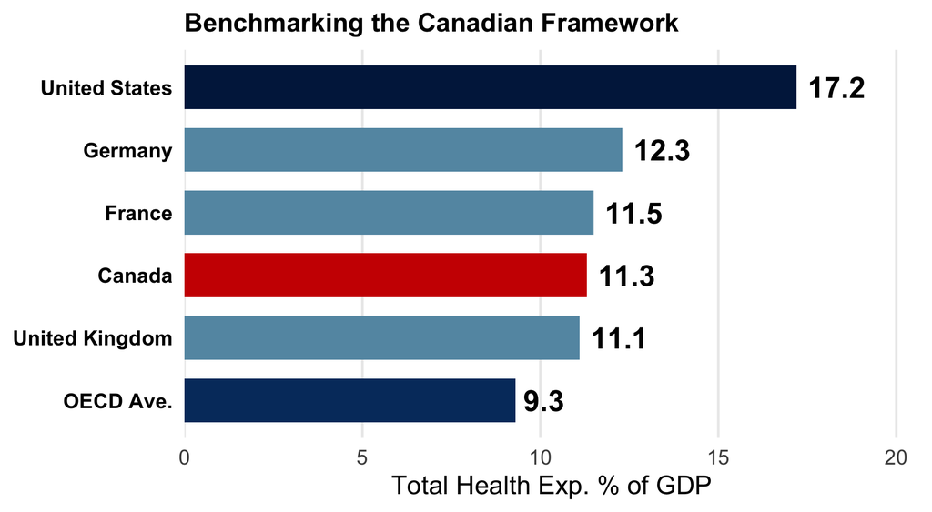

**System Lens:**

- Do differing health system frameworks inherently drive levels of financial input?
- Canadian framework relies on centralized financial leverage, not direct delivery management, to control these inputs.

## Expenditure v. Population Health (Macro Outcomes)

**Question**

- If the United States outspends Canada, and Canada outspends the OECD average, do the population health outcomes scale proportionately with the financial input?

**Key Empirical Insights:**

- **U.S:** The highest cost per capita, yet lags behind peer nations in baseline outcome measures like life expectancy.
- **Canada:** Demonstrates solid performance relative to the U.S., but often struggles to match the efficiency of top-performing European systems that spend less per capita.
- **The Insight:** High expenditure does not guarantee high value. A robust funding framework is necessary, but sufficient quality requires optimizing how funds are deployed.

## Expenditure v. Population Health (Macro Outcomes)

- If the United States outspends Canada, and Canada outspends the OECD average, do the population health outcomes scale proportionately with the financial input?

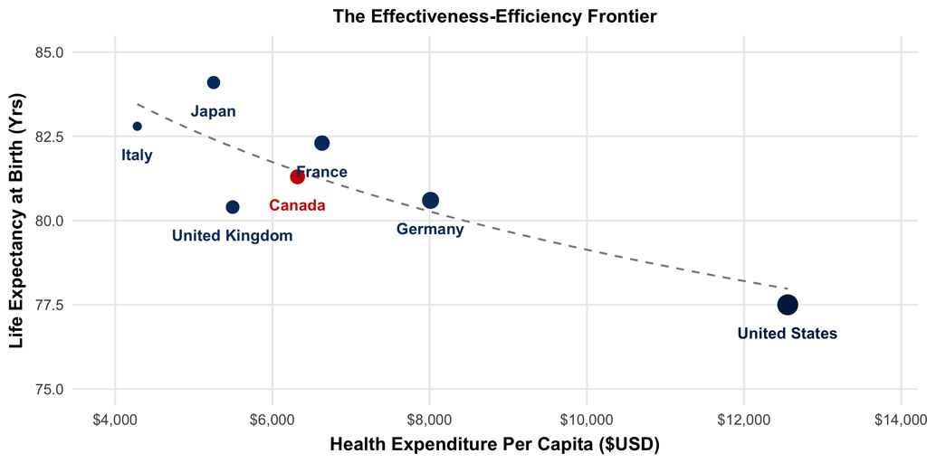

**Value v. Quality**

- High expenditure does not guarantee high value.
- Efficiency frontier demonstrating the diminishing returns of capital on population health.
- US has the highest cost per capita, yet falls entirely off the frontier.
- Canada demonstrates solid performance but sits slightly below the peak efficiency curve.

## Module 1.2

### Centralized v. Decentralized Governance

## Structural Governance

**The Pendulum**

- Healthcare governance in Canada frequently acts like a pendulum, swinging between highly centralized (provincial) and decentralized (regional).

**Centralized Governance**

- Decision-making, funding, and planning are consolidated at the highest level (e.g., Ontario).
- **Primary Goal:** Standardization, economies of scale, and macro-level equity.

**Decentralized Governance**

- Authority is devolved to regional or local bodies (e.g., Alberta).
- **Primary Goal:** Local responsiveness, community-tailored care, and micro-level efficiency.

**Source:** Armstrong, 1999

## Evaluating Governance Models: Trade-Offs

- To lead effectively, we must evaluate how the structural organization of a health system directly impacts the Value Framework:

$$Value = \frac{Outcomes}{Costs}$$

**Governance Trade-Offs in Health Systems**

Evaluating structural models through the Dual-Lens Strategy

| **Strategic Dimension** | **Centralized Model** | **Decentralized Model** |
| --- | --- | --- |
| Resource Allocation | Pooled risk, economies of scale | Fragmented risk pools |
| Local Responsiveness | Low (Rigid mandates) | High (Tailored to community needs) |
| Equity & Standardization | High (Standardized care pathways) | Variable ('Postal code lottery') |
| Administrative Overhead | Streamlined (Single-payer/manager) | Duplicative (Multiple IT/HR layers) |

## Governance and The Value Equation

**Structural Tension**

- How does the locus of control change the denominator (Costs) and numerator (Outcomes)?

**The System Lens (Public)**

- Centralization reduces administrative duplication (Cost $\downarrow$) and ensures the CHA pillar of *Universality* is uniformly applied (Outcomes $\uparrow$).
- **The Risk:** It creates massive, slow-moving bureaucracies that struggle to adapt to localized crises.

**The Industry Lens (Private)**

- Decentralization allows for rapid, localized technological adoption and agile partnerships with private-sector innovators (Outcomes $\uparrow$).
- **The Risk:** It fractures the market, meaning health systems lose purchasing power for pharmaceuticals and digital infrastructure (Cost $\uparrow$).

## Governance - The “Postal Code Lottery”

**Value v. Quality**

- When a system is highly decentralized, the quality of care and access to innovation often depends on the wealth and tax base of the specific region a patient lives in, challenging the core premise of Canadian health equity.

## Module 1.3

### Public v. Private Sector Interface

## The Canadian Paradox

- **The Myth:** Canada’s health system is frequently mischaracterized as a purely public.
- **The Reality:** A publicly financed system heavily reliant on private delivery mechanisms.
- **Primary Care:** The majority of physicians operate as independent contractors.

**Structural Tension**

- This dynamic creates a **structural tension** between macro-level equity goals (the public mandate) and micro-level operational efficiencies (private delivery).

**Source:** Machildon, 2012

## The Financial Interface

- To understand the public-private interface, we must visualize both the allocation of capital across sectors and the origin of that capital.
- Canada’s total health expenditure exceeds CAD$330 Billion (~11.2% of GDP), sitting between the UK (~11.1%) and the US (~16.6%).
- For more information on Canadian healthcare spending and trends, the Canadian Institute for Health Information (CIHI) is an excellent source and can be found at the link below:

[Canadian Institute for Health Information](https://www.cihi.ca/en/national-health-expenditure-trends)

## Sector Allocation & Source

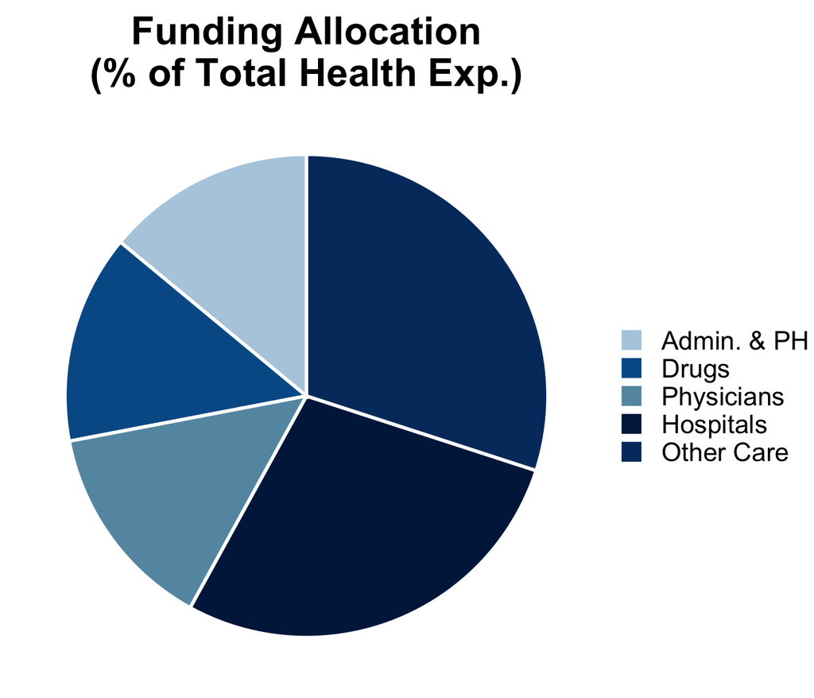

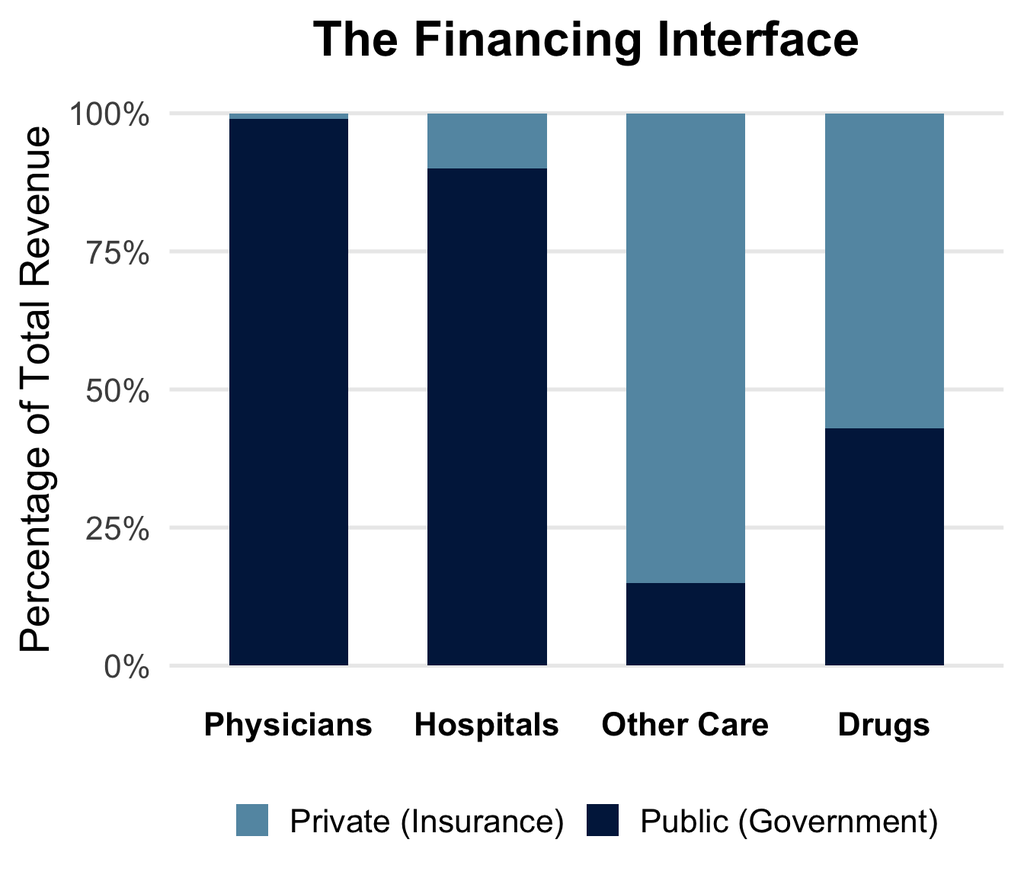

## The Private Sector Footprint

**Background:**

- The private sector extends far beyond independent clinical practice into critical system infrastructure.
- Private insurance and out-of-pocket payments fund approximately 30% of total health expenditures in Canada.

**Key Domains of Private Innovation:**

- Pharmaceutical development and the generation of Real-World Evidence (RWE).
- Digital infrastructure, electronic medical records, and analytical platforms.
- Extended health services not covered by the CHA (e.g., dental, vision, outpatient physiotherapy).

## Evaluating the Interface: Economies of Scale

**Public Sector Advantage:**

- **Purchasing Power:** Centralized, public funding allows for economies of scale (e.g., pan-Canadian pharmaceutical negotiations).
- **Systemic Equity:** Leverages broad risk pools to ensure standardized care pathways across diverse populations.

**Private Sector Advantage:**

- **Agility:** Private delivery mechanisms can rapidly adapt operational workflows and adopt novel clinical protocols.
- **Capital Injection:** Private entities can fund specialized facility-level infrastructure that public budgets cannot immediately support.

## Costing the Interface: A PPPY Perspective

- When public funding meets private delivery, evaluating treatment costs Per Patient Per Year (PPPY) is essential to determine true value.
- Analyzing facility-level data allows health system leaders to identify precisely where private delivery models optimize costs without sacrificing the quality of care.

**The Evaluation Imperative**

- We must rely on clinically meaningful changes in patient outcomes to justify private-sector integration.
- Cost reduction through private delivery is only valuable if it maintains or improves population-centred equity.

## International Comparators: The Interface Abroad

- To understand Canada’s position, we evaluate the public-private mix of peer nations.

| Country | Financing | Delivery | Implication |
| --- | --- | --- | --- |
| **United Kingdom** | Public | Public | **Pro:** Control & Integrated **Con:** Efficiency |
| **United States** | Private | Private | **Pro:** Innovation **Con:** Barriers |
| **Canada** | Public | Private | Striving for Equity & Agility |

## Optimizing the System Interface for the Future

- **Identifying Systemic Barriers:** Requires synthesizing the relationship between potential access and realized utilization across both sectors.
- **Moving Past Ideological Debates:** Requires evidence-based integration is required to successfully implement large-scale interventions.
- **The Leadership Challenge:** How can public regulators effectively incentivize private innovation without widening health disparities?

## Module 1.4

### The Value Framework & Defining Value

## Defining Value in Health Care

- In healthcare, the overarching goal must be to maximize **value** for patients, not simply to lower costs or increase the volume of services.
- Value is defined as the health outcomes achieved per dollar spent.

**The Standard Equation**

$$Value = \frac{Outcomes}{Costs}$$

- **Strategic Implication:** Value encompasses both efficiency and effectiveness. If costs are reduced but outcomes suffer, value is destroyed. If outcomes improve but costs become unsustainable, value is equally compromised.

**Source:** Armstrong, 1999

## Deconstructing the Numerator

**Health Outcomes:**

- Outcomes are the health states achieved that matter most to patients, not just isolated clinical or biological markers.
- In a value-based system, outcomes are inherently multidimensional and should be measured across the full cycle of care.

**Outcome Tiers:**

1. **Health Status Achieved:** Survival rates and the degree of health or clinical recovery.
2. **Process of Recovery:** Time to recovery and the disutility of care or treatment.
3. **Sustainability of Health:** Long-term consequences of therapy.

## Deconstructing the Denominator

- The denominator represents the total costs incurred over the full cycle of care for the patient’s medical condition.
- It is not simply the cost of a single intervention (e.g., an individual surgery or a monthly pharmaceutical prescription).

**Costing Methodologies**

- **Measurement:** Leaders must move beyond aggregate departmental budgets.
- **PPPY:** Evaluate treatment costs is an accurate measure of disease management (e.g., diabetes).
- **Optimization:** True cost reduction involves optimizing the entire care pathway.
- **Goal:** Reduce the need for expensive downstream interventions.

$$\text{PPPY} = \text{Per Patient Per Year}$$

## The Value Plane: Visualizing the Ratio

*Hover over the facilities below to evaluate specific PPPY costs and outcome scores.*

[interactive chart not shown]

## Value versus Volume

- A primary driver of inefficiency in health systems is the misalignment of funding models with the Value Framework.

**Volume-Based (Fee-for-Service)**

- Providers are compensated based on the quantity of services delivered (e.g., number of visits, tests, or procedures).
- Can inadvertently incentivize over-utilization and fragment the care pathway across different specialists.

**Value-Based Care**

- Funding is tied to the clinical and population-level outcomes achieved relative to the cost of delivering those outcomes.
- Incentivizes preventative care, economies of scale, and multi-disciplinary collaboration.

## Quantifying Value for Leadership

- Theoretical frameworks are insufficient without robust empirical measurement.
- To operationalize the Value Framework, health system leaders must rely on longitudinal health outcome data and facility-level cost analyses.

**The Data & Analytics Connection:**

- In our `R-Laboratory` sessions, we will transition from defining value conceptually to measuring it quantitatively.
- We will learn how to analyze raw datasets, visualize potential access versus realized utilization, and isolate outcome-to-cost ratios to drive evidence-based strategic decisions.

## Module 1 Summary: Macro Governance to Micro-Level Value

- **The Canadian Health Act:** Explored how federal transfer payments (CHT) use economic leverage and the **Five Pillars** to maintain system-wide equity.
- **Governance Models:** Analyzed the structural trade-offs between centralized standardization and decentralized responsiveness.
- **Public-Private Interface:** Dissected the Canadian paradox—publicly funded care delivered primarily through private mechanisms—and evaluated the financing interface across sectors.
- **Value Framework:** Established the foundational equation contrasting volume-driven fee models with patient-centred, value-based care delivery.

## Student Evaluation

Following our Week 1 R-Laboratory, we will dedicate the last 10 minutes for student participation in a Week 1 Evaluation.

**Objective**:

- Students will complete a short Evaluation of the Week 1 curriculum, including the Module 1 lecture material and the R-Laboratory session.
- Student **responses are anonymous** and are critical for improving the delivery and structure of future lecture modules and R-Laboratories.

## Capstone Taskforce (Group Work)

- Following our Week 1 Student Evaluation, we will dedicate the last 20-30 minutes of the class for the Capstone Taskforce formation.
- **Objective:** Form a Taskforce of **5** members.
- **Deliverable:** Email the instructor of your Taskforce members.

### Email Instructions

**Subject Heading:** MHIA 6160 Capstone Taskforce

**Email:** Dr. Chiarot

**Note:** Only one Taskforce member is required to email the instructor.

## Next Steps: Getting Ready for the R-Labs

### Software Prerequisites

1. **Install R:** Download the version matching your `OS`.
2. **Install RStudio Desktop:** Download the free desktop edition from Posit.
3. **Verify Setup:** Open `RStudio` and ensure the `R` version prints in the console.

**Local File Hygiene**

Build an `R Project` (`.Rproj`) to securely anchor your working directories.